# OR-568 Project Report

Maazuddin Mohammed(G01192302), Amrita Jose(G01233664), Asmita Singh(G01212983), Yeshwanth Reddy Bommu(G01197092)

May 7, 2020

# 1 Project and Dataset Description.

The goal of this analysis is to determine the popularity of a news article based on the number of shares or the number of times the article has been shared on any social network or platform.The response/target variable is the number of shares which is predicted using a couple of feature/predictor variables.

### 1.0.1 Importance Of the Project

Accelerated growth of online news service and social media have increased the importance of learning and understanding readers’ unseen behavioural patterns.We can predict the popularity of an online news article and determine whether it will draw significant attention.Finding out the relationship between the response variable (Number of shares) and other predictors, we can build a model that helps us decide the content of articles or the timing of the release to maximize the popularity of the articles.

### 1.0.2 Methods/Models Used For The Project.

##### 1.0.2.0.1 The following methods/models have been used to predict the popularity of news: -

- **1. K NEAREST NEIGHBOUR(KNN)**
- **2. CLASSIFICATION AND REGRESSION TREES(CART)**
- **3. NAIVE BAYES**
- **4. RANDOM FOREST**
- **5. LOGISTIC REGRESSION**
- **6. SVM (Memory Issues)**
- **7. LINEAR REGRESSION**

### 1.0.3 Criteria for Best Model Selection.

We have used both Accuracy and F1 score to determine the best model. The model with the highest value of accuracy and F1 score has been selected as the best model.

# 2 Libraries

```r
## Import the libraries
library(gmodels)
library(caret)
library(class)
library(pROC)
library(rpart)
library(rattle)
library(dplyr)
library(e1071)
library(tidyverse)
```

```r
library(corrplot)
library(prediction)
library(ROCR)
library(randomForest)
```

## 2.1 Basic operations

### 2.1.1 Read the file

```r
#setwd("C:/Users/majaa/Desktop/OR-568/Project")
#setwd("C:/Users/Asmita Singh/Documents/GMU/OR 568/data")
setwd("C:/Users/Amrita/Documents/GMU/OR 568/Datasets/data")
news <- read.csv("OnlineNewsPopularity.csv", stringsAsFactors = FALSE)
```

### 2.1.2 Perform basic exploratory operations

```r
str(news)
```

```
## 'data.frame':    39644 obs. of  61 variables:
##  $ url                          : chr  "http://mashable.com/2013/01/07/amazon-instant-video-browser/" "http://mashable.com/2013/01/07/ap-samsung-sponsored-tweets/" "http://mashable.com/2013/01/07/apple-40-billion-app-downloads/" "http://mashable.com/2013/01/07/astronaut-notre-dame-bcs/" ...
##  $ timedelta                    : num  731 731 731 731 731 731 731 731 731 731 ...
##  $ n_tokens_title               : num  12 9 9 9 13 10 8 12 11 10 ...
##  $ n_tokens_content             : num  219 255 211 531 1072 ...
##  $ n_unique_tokens              : num  0.664 0.605 0.575 0.504 0.416 ...
##  $ n_non_stop_words             : num  1 1 1 1 1 ...
##  $ n_non_stop_unique_tokens     : num  0.815 0.792 0.664 0.666 0.541 ...
##  $ num_hrefs                    : num  4 3 3 9 19 2 21 20 2 4 ...
##  $ num_self_hrefs               : num  2 1 1 0 19 2 20 20 0 1 ...
##  $ num_imgs                     : num  1 1 1 1 20 0 20 20 0 1 ...
##  $ num_videos                   : num  0 0 0 0 0 0 0 0 0 1 ...
##  $ average_token_length         : num  4.68 4.91 4.39 4.4 4.68 ...
##  $ num_keywords                 : num  5 4 6 7 7 9 10 9 7 5 ...
##  $ data_channel_is_lifestyle    : num  0 0 0 0 0 0 1 0 0 0 ...
```

[output cut: 47 more lines]

```r
summary(news$shares)
```

```
##    Min. 1st Qu.  Median    Mean 3rd Qu.    Max.
##       1     946    1400    3395    2800  843300
```

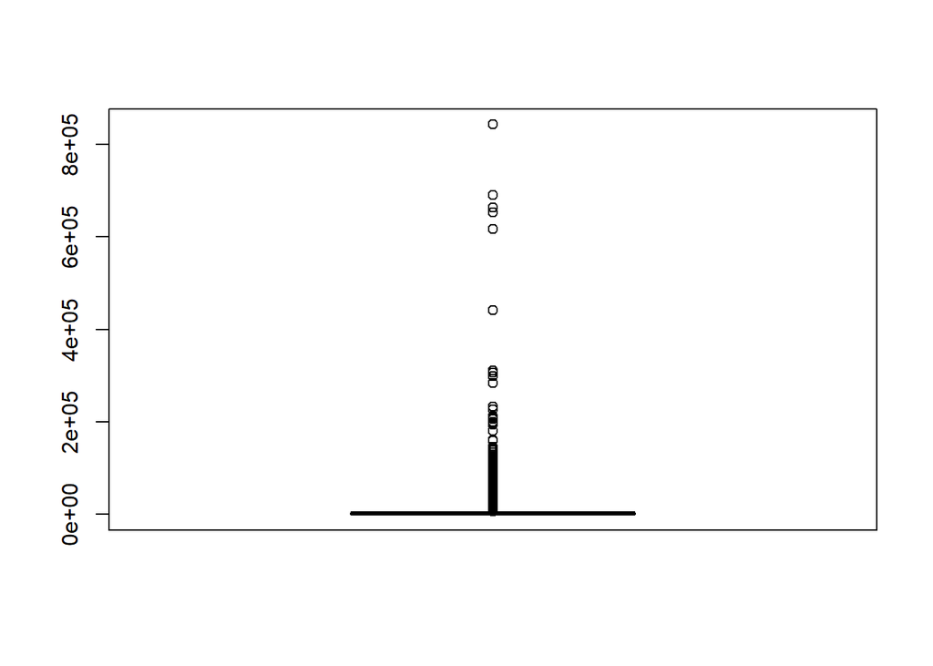

```r
boxplot(news$shares)
```

```r
length(news$shares)
```

```
## [1] 39644
```

### 2.1.3 Finding Missing Values and removing outliers

```r
# Check for any missing values:
sum(is.na(news))
```

```
## [1] 0
```

```r
# The data has no missing values

# Based on the summary of the dataset above, it can be seen that there is outlier in "n_unique_tokens", "n_non_stop_words", and "n_non_stop_unique_tokens". Hence removing that observation
news <- news[!news$n_unique_tokens==701,]
```

## 2.2

# 3 Exploratory Data Analysis

## 3.1 Removing Columns

```r
# Remove url and timedelta from the dataset using subset, as url and timedelta are non predictive variables
news <- subset(news, select = -c(url, timedelta))
news$shares<- as.numeric(news$shares)
newsexplore<-news
```

## 3.2 Plots

### 3.2.1 Heat Map

Heat Map for Correlation between all variables

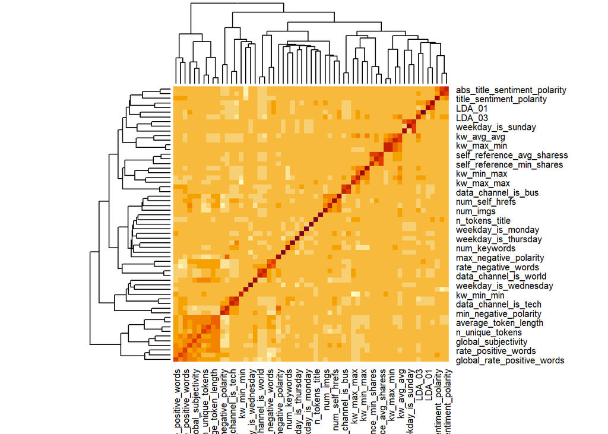

```r
cormatrix <- cor(newsexplore)
heatmap(cormatrix)
```

```r
#From the above heatmap it can be observed that certain groups of variables are close to each other.
#However, all variables have low correlation with the target variable - number of shares.
```

### 3.2.2 Combined Plots For EDA.

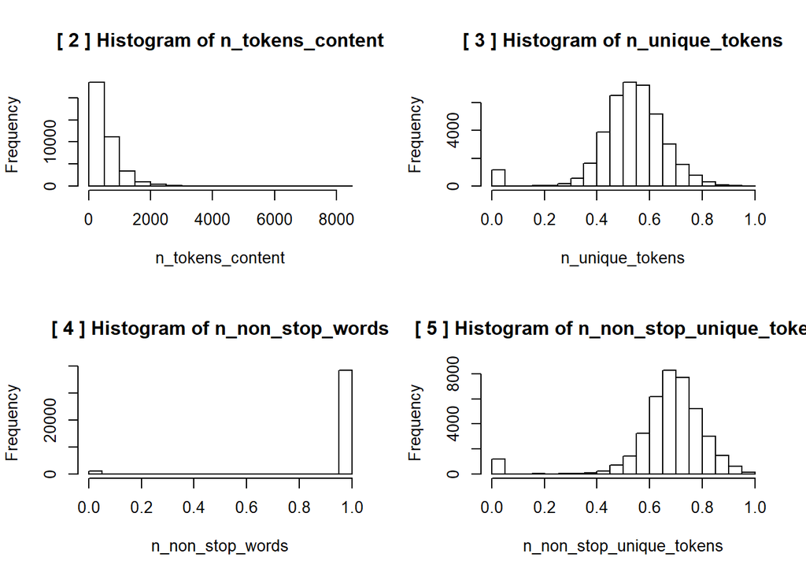

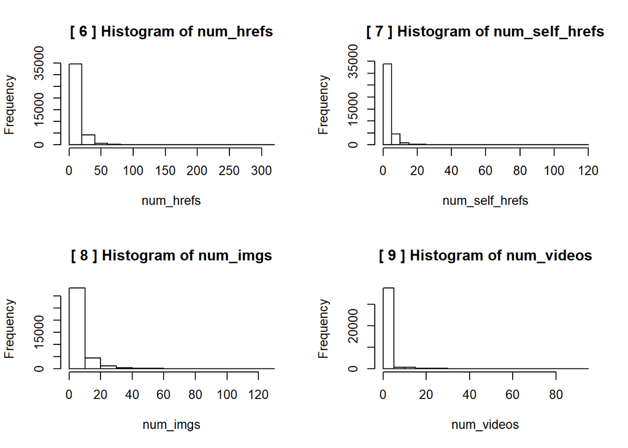

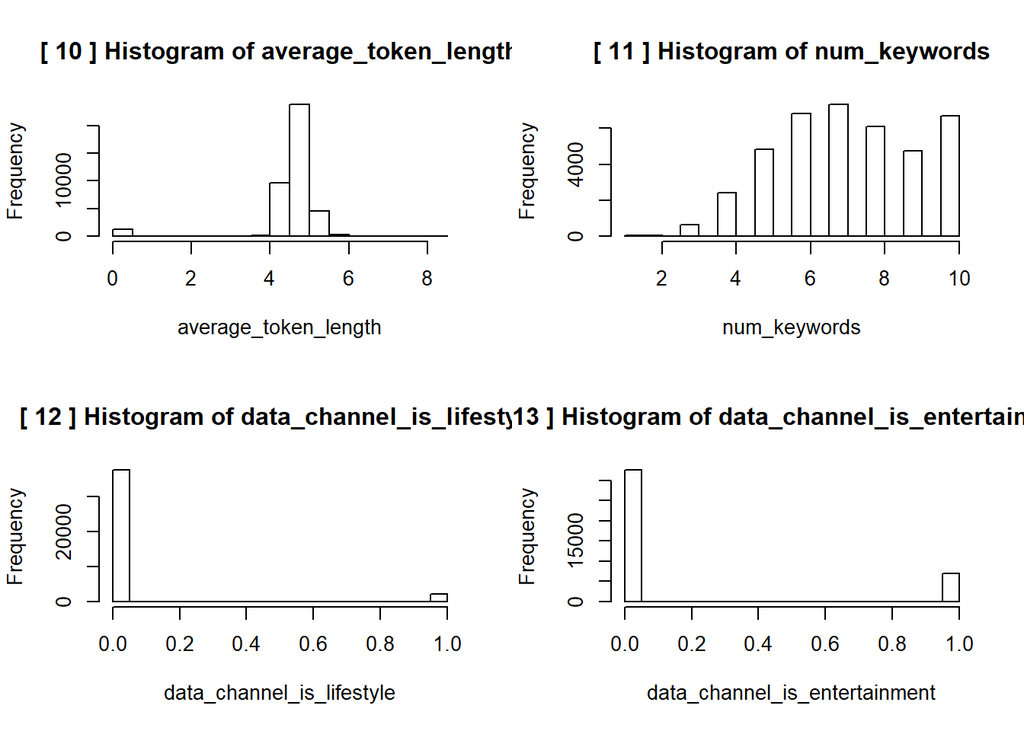

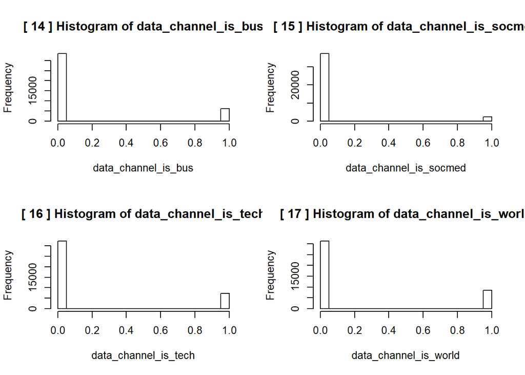

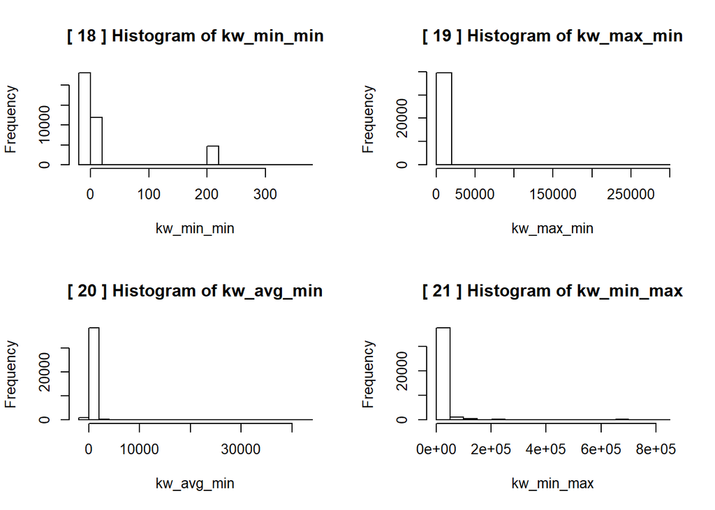

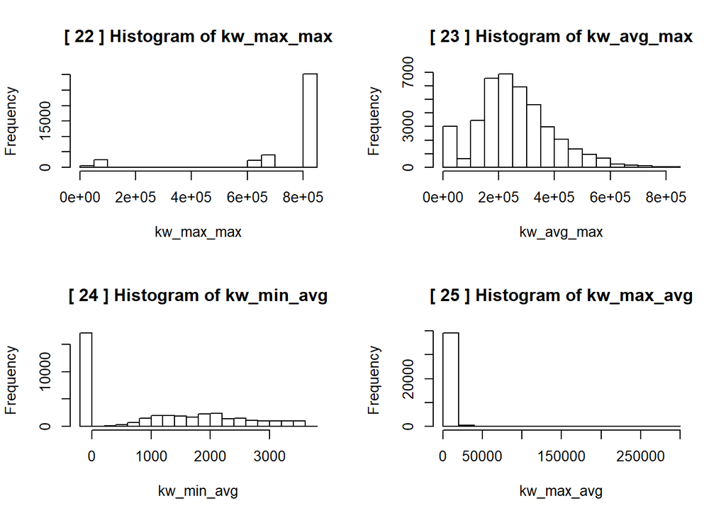

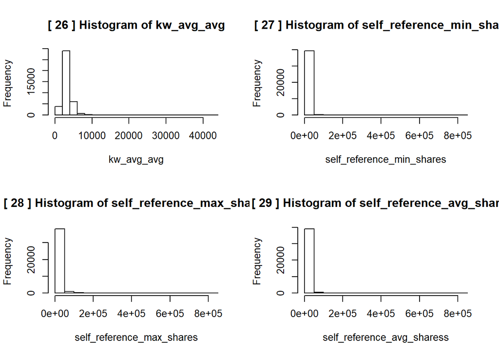

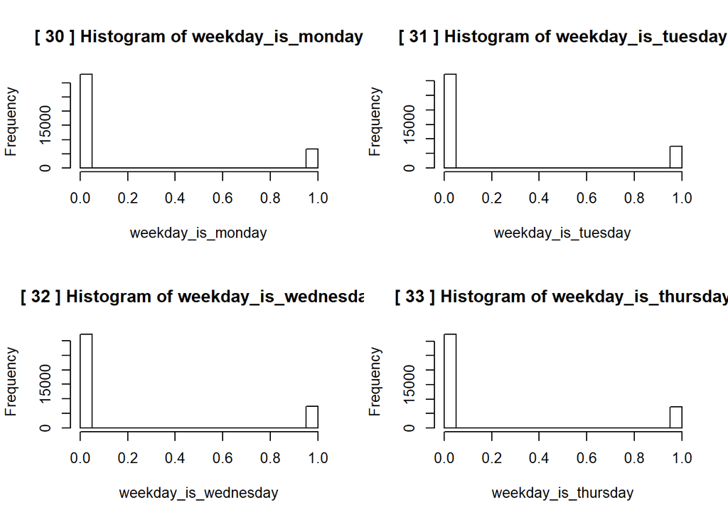

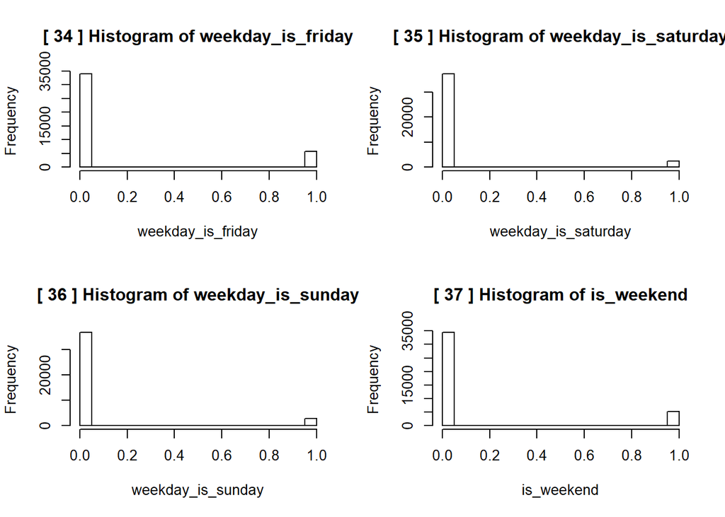

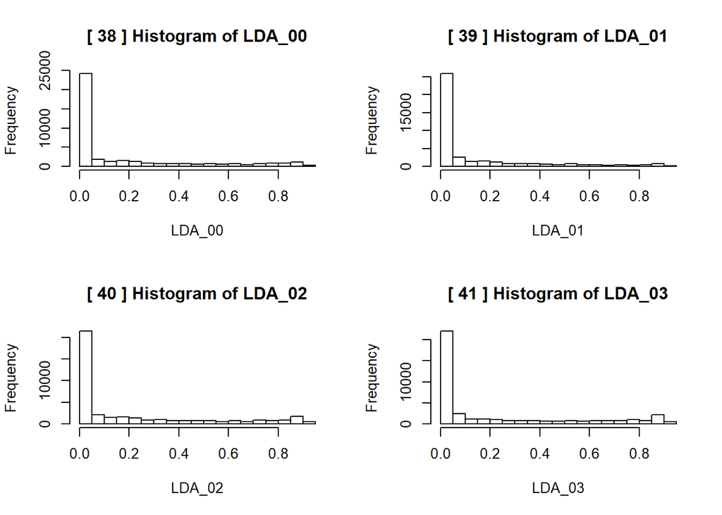

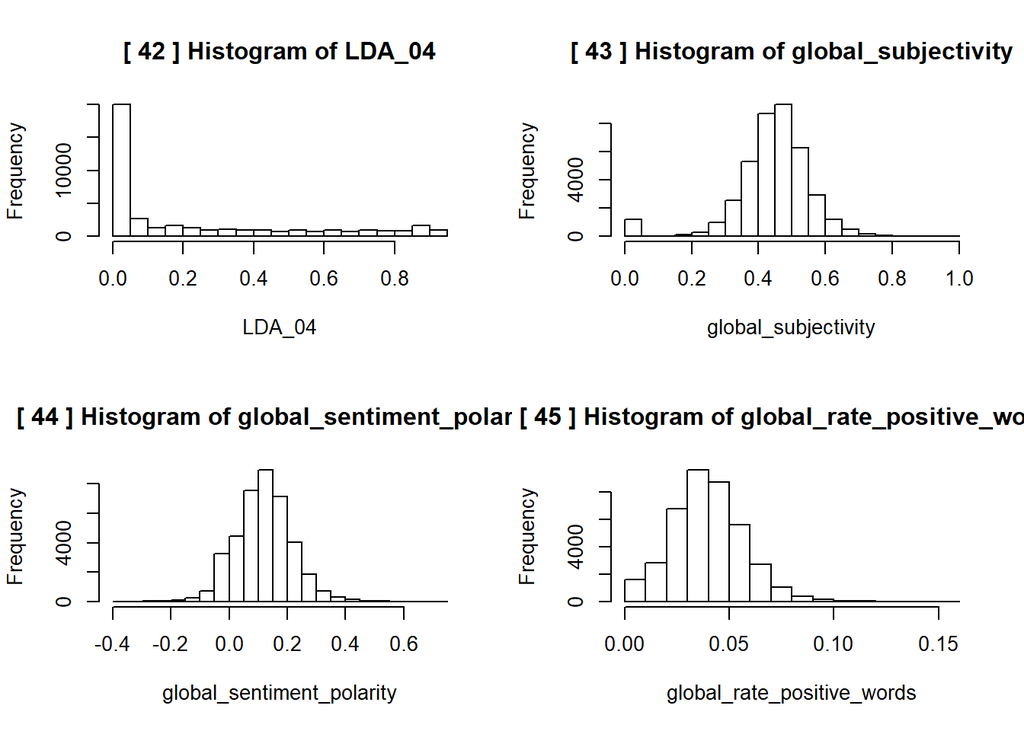

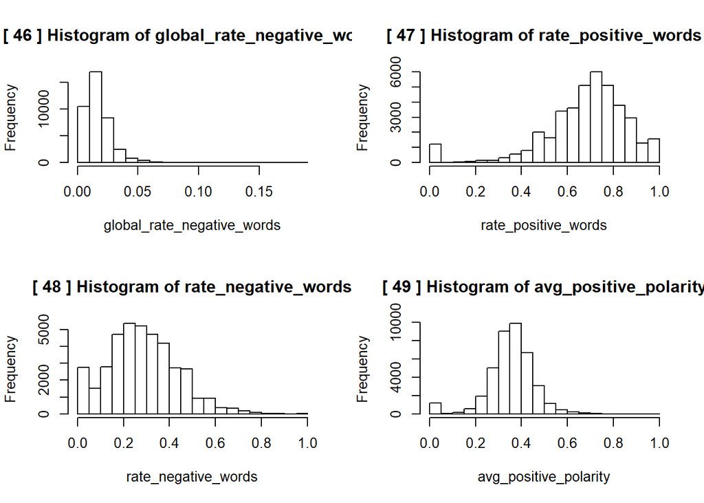

[2 more figures not shown]

```r
#Combining Plots for EDA for visual analysis
par(mfrow=c(2,2))
for(i in 2:length(news)){hist(news[,i],
                              xlab=names(news)[i] , main = paste("[" , i , "]" ,
                                                                 "Histogram of", names(news)[i])  )}
```

```r
# From the above data distributions, the following can be observed:-
# 1. there is outlier in "n_unique_tokens", "n_non_stop_words", and "n_non_stop_unique_tokens"
# 2. The dataset could possibly have some missing values which might be coded as 0 and hence difficult to find
# 3. Based on the distributions, it can be seen that the data is skewed to some extent.
```

[figure not shown]

### 3.2.3 Weekdays and Weekends

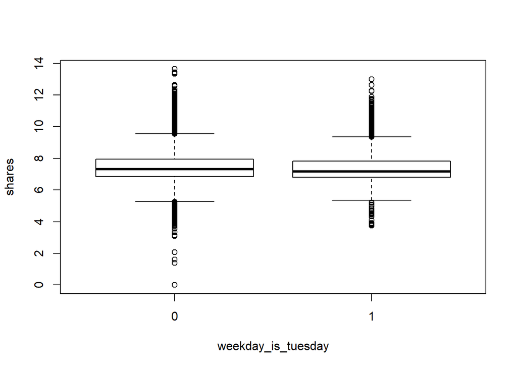

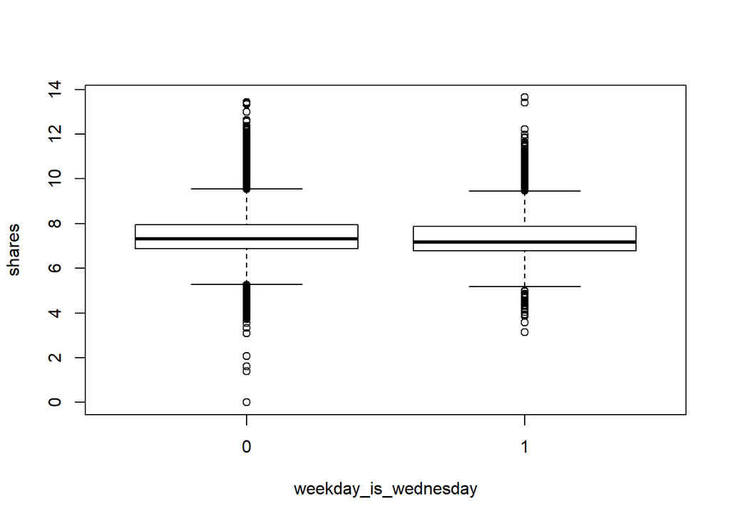

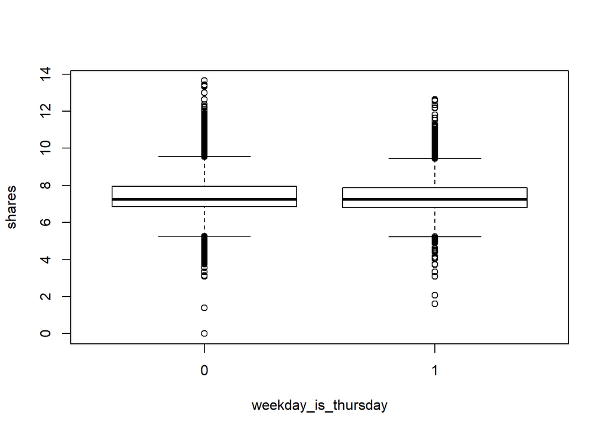

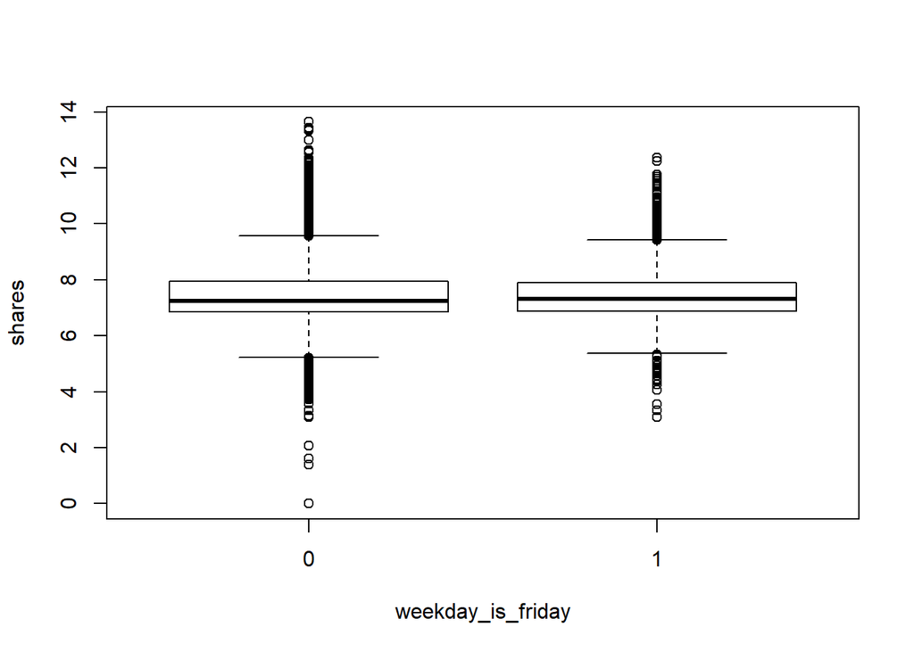

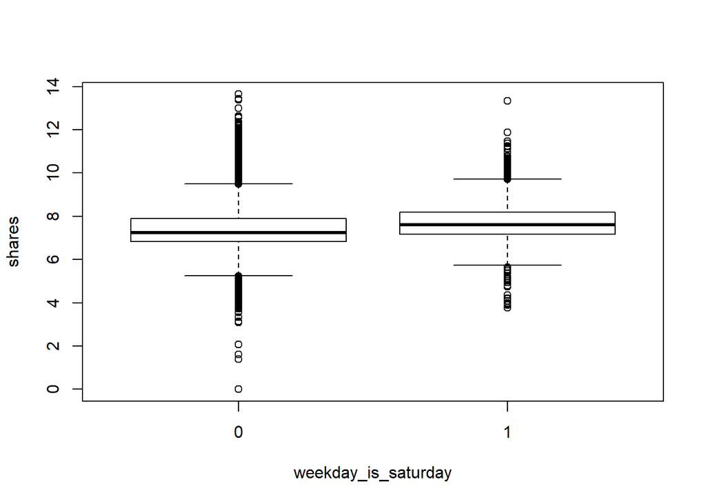

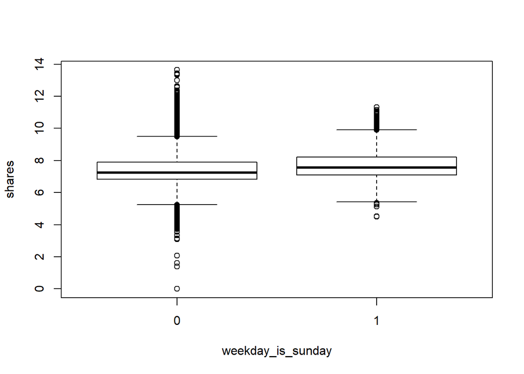

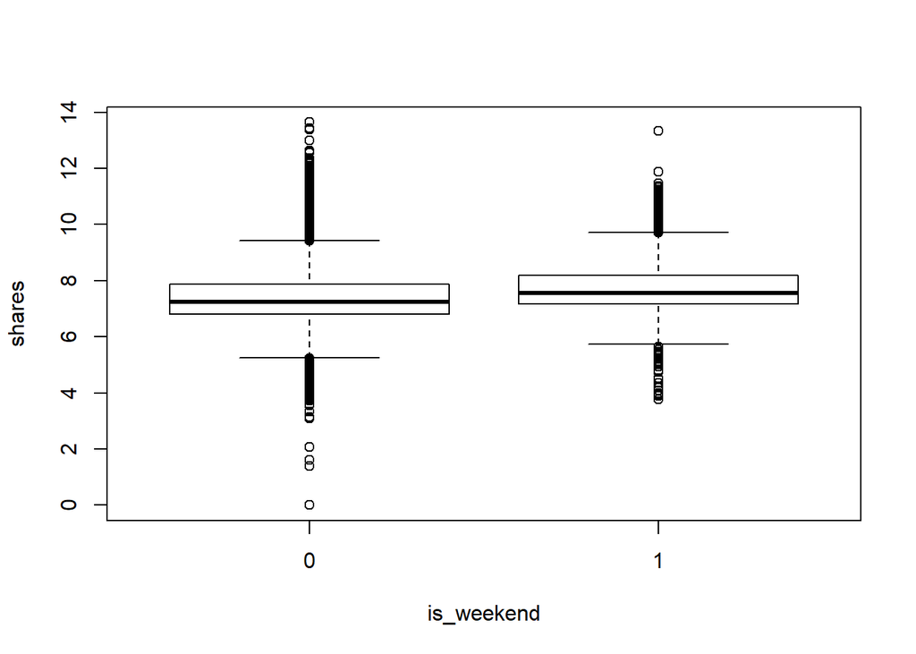

```r
# Determining the effect of weekdays and weekends on number of shares
for (i in 31:37){
  boxplot(log(news$shares) ~ (news[,i]), xlab=names(news)[i] , ylab="shares")
}
```

```r
# Observing the above box plots, it can be said that weekdays show some effect on shares.However, they can also be chosen to be not considered due to the very small effect.
# However, weekends seem to have more considerable effect.
```

### 3.2.4 Effect on Shares

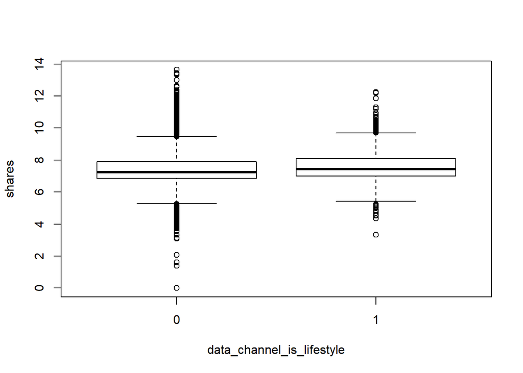

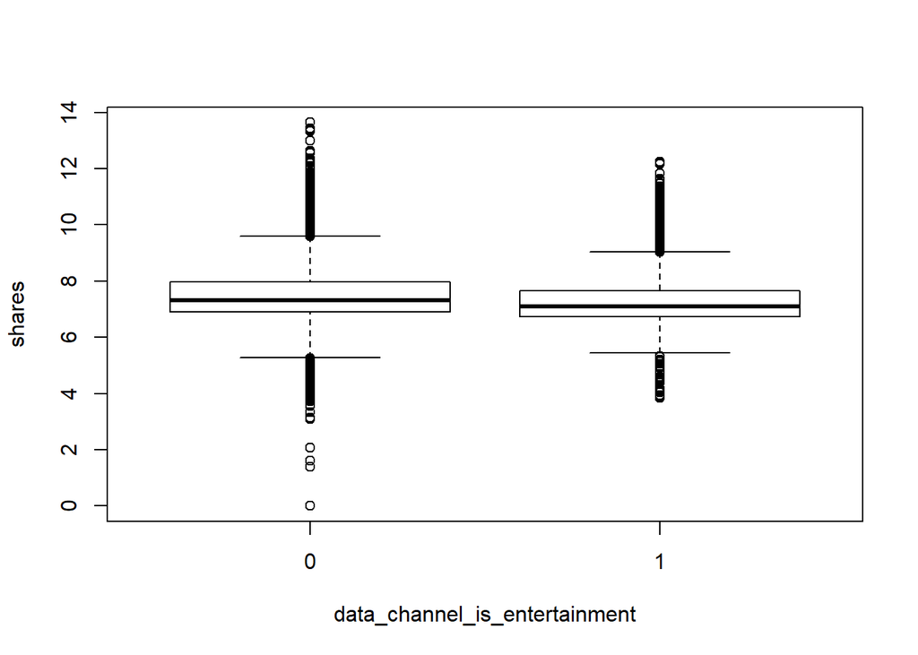

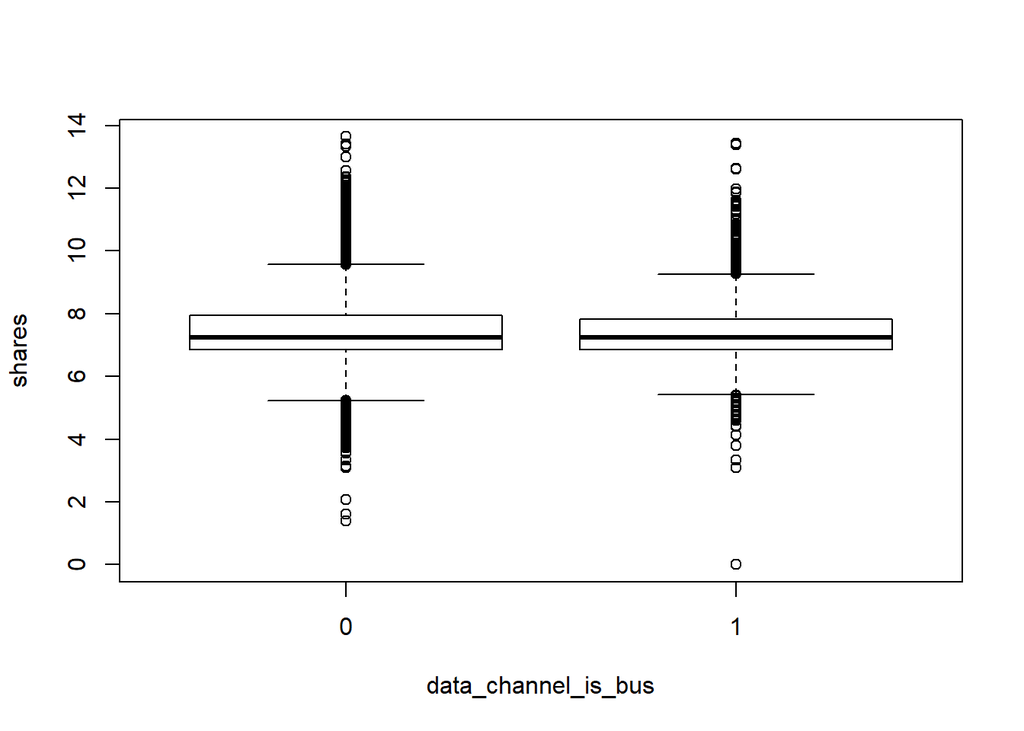

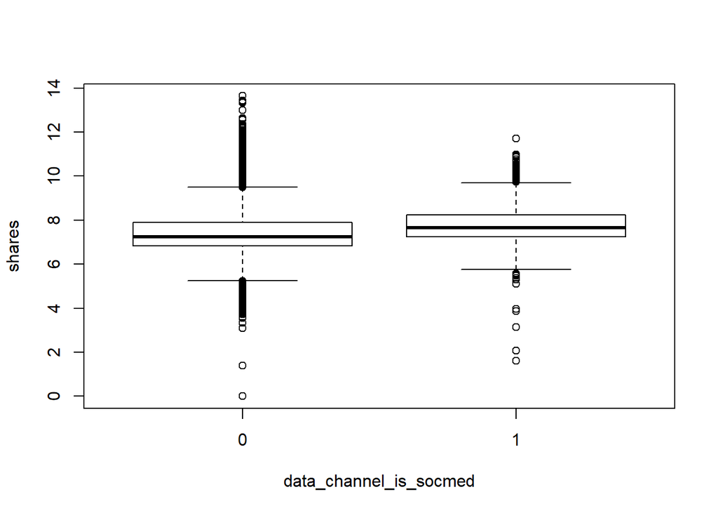

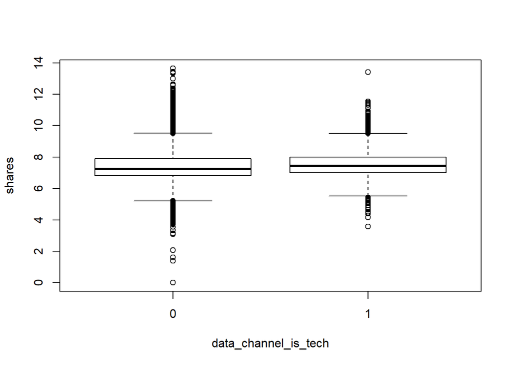

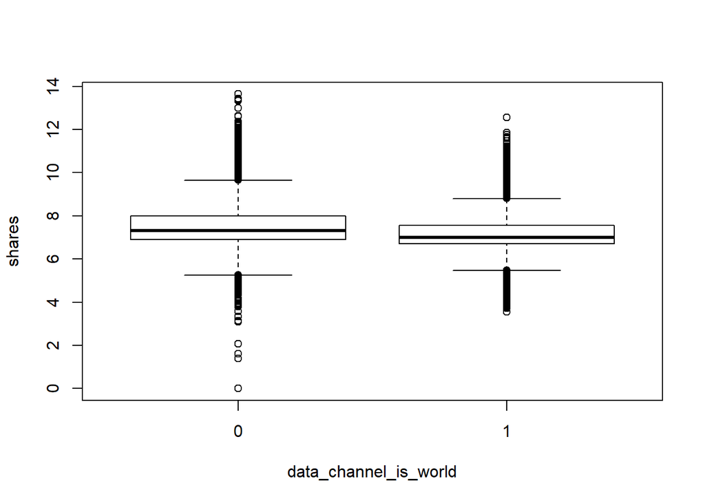

```r
# Determining the effect of news categories on shares
for (i in 12:17){
  boxplot(log(news$shares) ~ (news[,i]), xlab=names(news)[i] , ylab="shares")
}
```

```r
#Observing the boxplots, news categories also seem to have very small effect on the number of shares and can be ignored if required.
```

## 3.3

# 4 Predictive Models

## 4.1 Converting response variable to factors with two levels.

```r
# Converting shares to response varai ble with 1400 as median value
news$shares <- as.factor(ifelse(news$shares >1400,1,0))

# get the number of 1's and 0's
table(news$shares)
```

```
##
##     0     1
## 20082 19561
```

```r
# Results in percentage form
round(prop.table(table(news$shares)) * 100, digits = 1)
```

```
##
##    0    1
## 50.7 49.3
```

Here 1 Represents that the shares are greater than 1400 and hence they are popular, whereas 0 represents the opposite.

## 4.2 Models

### 4.2.1 KNN

```r
# KNN which stand for K Nearest Neighbor is a Supervised Machine Learning algorithm that classifies a new data point into the target class, depending on the features of its neighboring data points.
# K-Nearest Neighbor based classifier classifies a query instance based on the class labels of its neighbor instances where new data are classified based on stored, labeled
# instances. It classifies data points based on the points that are most similar to it and uses test data to make an âeducated guessâ
# on what an unclassified point should be classified as. Online popularity news dataset.

# Data Normalization
# Normalization
normalize <- function(x) {
  return ((x - min(x))/(max(x) - min(x)))}

news.subset.n <- as.data.frame(lapply(news[,1:58], normalize))
head(news.subset.n)
```

|  | n_tokens_title | n_tokens_content | n_unique_tokens | n_non_stop_words | n_non_stop_unique_tokens | num_hrefs | num_self_hrefs | num_imgs | num_videos | average_token_length | num_keywords | data_channel_is_lifestyle | data_channel_is_entertainment | data_channel_is_bus | data_channel_is_socmed | data_channel_is_tech | data_channel_is_world | kw_min_min | kw_max_min | kw_avg_min | kw_min_max | kw_max_max | kw_avg_max | kw_min_avg | kw_max_avg | kw_avg_avg | self_reference_min_shares | self_reference_max_shares | self_reference_avg_sharess | … |
| --- | --- | --- | --- | --- | --- | --- | --- | --- | --- | --- | --- | --- | --- | --- | --- | --- | --- | --- | --- | --- | --- | --- | --- | --- | --- | --- | --- | --- | --- | --- |
| 1 | 0.4761905 | 0.02584376 | 0.6635945 | 1 | 0.8153846 | 0.013157895 | 0.01724138 | 0.0078125 | 0 | 0.5820240 | 0.4444444 | 0 | 1 | 0 | 0 | 0 | 0 | 0.002645503 | 0 | 2.334874e-05 | 0 | 0 | 0 | 0.0002766987 | 0 | 0 | 0.0005881655 | 0.0005881655 | 0.0005881655 | … |
| 2 | 0.3333333 | 0.03009205 | 0.6047431 | 1 | 0.7919463 | 0.009868421 | 0.00862069 | 0.0078125 | 0 | 0.6110433 | 0.3333333 | 0 | 0 | 1 | 0 | 0 | 0 | 0.002645503 | 0 | 2.334874e-05 | 0 | 0 | 0 | 0.0002766987 | 0 | 0 | 0.0000000000 | 0.0000000000 | 0.0000000000 | … |
| 3 | 0.3333333 | 0.02489969 | 0.5751295 | 1 | 0.6638656 | 0.009868421 | 0.00862069 | 0.0078125 | 0 | 0.5463342 | 0.5555556 | 0 | 0 | 1 | 0 | 0 | 0 | 0.002645503 | 0 | 2.334874e-05 | 0 | 0 | 0 | 0.0002766987 | 0 | 0 | 0.0010885806 | 0.0010885806 | 0.0010885806 | … |
| 4 | 0.3333333 | 0.06266226 | 0.5037879 | 1 | 0.6656347 | 0.029605263 | 0.00000000 | 0.0078125 | 0 | 0.5477682 | 0.6666667 | 0 | 1 | 0 | 0 | 0 | 0 | 0.002645503 | 0 | 2.334874e-05 | 0 | 0 | 0 | 0.0002766987 | 0 | 0 | 0.0000000000 | 0.0000000000 | 0.0000000000 | … |
| 5 | 0.5238095 | 0.12650460 | 0.4156456 | 1 | 0.5408895 | 0.062500000 | 0.16379310 | 0.1562500 | 0 | 0.5823312 | 0.6666667 | 0 | 0 | 0 | 0 | 1 | 0 | 0.002645503 | 0 | 2.334874e-05 | 0 | 0 | 0 | 0.0002766987 | 0 | 0 | 0.0006462706 | 0.0189730819 | 0.0037366986 | … |
| 6 | 0.3809524 | 0.04366297 | 0.5598886 | 1 | 0.6981982 | 0.006578947 | 0.01724138 | 0.0000000 | 0 | 0.5421179 | 0.8888889 | 0 | 0 | 0 | 0 | 1 | 0 | 0.002645503 | 0 | 2.334874e-05 | 0 | 0 | 0 | 0.0002766987 | 0 | 0 | 0.0100794498 | 0.0100794498 | 0.0100794498 | … |

```r
# Data Splicing
set.seed(1)
news_dataset <- sample(2, nrow(news.subset.n), replace=TRUE, prob=c(0.80, 0.20))

# Creating seperate dataframe for predictors
news.training <- news[news_dataset==1, 1:58]
news.test <- news[news_dataset==2, 1:58]

# Creating seperate dataframe for 'shares' feature which is our target.
news.trainLabels <- news[news_dataset==1, 59]
news.testLabels <- news[news_dataset==2, 59]

newsdatatraining <- news[news_dataset==1, 1:59]
newsdatatest <- news[news_dataset==2, 1:59]

# Building a KNN Machine Learning model
news_pred1 <- knn(train = news.training, test = news.test, cl = news.trainLabels, k=1)
confusionMatrix(table(news_pred1 ,news.testLabels))
```

```
## Confusion Matrix and Statistics
##
##           news.testLabels
## news_pred1    0    1
##          0 2220 1864
##          1 1746 2063
##
##                Accuracy : 0.5426
##                  95% CI : (0.5316, 0.5537)
##     No Information Rate : 0.5025
##     P-Value [Acc > NIR] : 5.028e-13
##
##                   Kappa : 0.0851
##
##  Mcnemar's Test P-Value : 0.0515
##
##             Sensitivity : 0.5598
##             Specificity : 0.5253
##          Pos Pred Value : 0.5436
##          Neg Pred Value : 0.5416
##              Prevalence : 0.5025
##          Detection Rate : 0.2813
##    Detection Prevalence : 0.5174
##       Balanced Accuracy : 0.5425
##
##        'Positive' Class : 0
##
```

```r
news_pred5 <- knn(train = news.training, test = news.test, cl = news.trainLabels, k=5)
confusionMatrix(table(news_pred5 ,news.testLabels))
```

```
## Confusion Matrix and Statistics
##
##           news.testLabels
## news_pred5    0    1
##          0 2333 1782
##          1 1633 2145
##
##                Accuracy : 0.5673
##                  95% CI : (0.5563, 0.5783)
##     No Information Rate : 0.5025
##     P-Value [Acc > NIR] : < 2e-16
##
##                   Kappa : 0.1345
##
##  Mcnemar's Test P-Value : 0.01132
##
##             Sensitivity : 0.5883
##             Specificity : 0.5462
##          Pos Pred Value : 0.5670
##          Neg Pred Value : 0.5678
##              Prevalence : 0.5025
##          Detection Rate : 0.2956
##    Detection Prevalence : 0.5213
##       Balanced Accuracy : 0.5672
##
##        'Positive' Class : 0
##
```

```r
news_pred10 <- knn(train = news.training, test = news.test, cl = news.trainLabels, k=10)
confusionMatrix(table(news_pred10 ,news.testLabels))
```

```
## Confusion Matrix and Statistics
##
##            news.testLabels
## news_pred10    0    1
##           0 2393 1792
##           1 1573 2135
##
##                Accuracy : 0.5737
##                  95% CI : (0.5627, 0.5846)
##     No Information Rate : 0.5025
##     P-Value [Acc > NIR] : < 2.2e-16
##
##                   Kappa : 0.1471
##
##  Mcnemar's Test P-Value : 0.0001712
##
##             Sensitivity : 0.6034
##             Specificity : 0.5437
##          Pos Pred Value : 0.5718
##          Neg Pred Value : 0.5758
##              Prevalence : 0.5025
##          Detection Rate : 0.3032
##    Detection Prevalence : 0.5302
##       Balanced Accuracy : 0.5735
##
##        'Positive' Class : 0
##
```

```r
news_pred15 <- knn(train = news.training, test = news.test, cl = news.trainLabels, k=15)
confusionMatrix(table(news_pred15 ,news.testLabels))
```

```
## Confusion Matrix and Statistics
##
##            news.testLabels
## news_pred15    0    1
##           0 2458 1793
##           1 1508 2134
##
##                Accuracy : 0.5818
##                  95% CI : (0.5708, 0.5927)
##     No Information Rate : 0.5025
##     P-Value [Acc > NIR] : < 2.2e-16
##
##                   Kappa : 0.1632
##
##  Mcnemar's Test P-Value : 7.691e-07
##
##             Sensitivity : 0.6198
##             Specificity : 0.5434
##          Pos Pred Value : 0.5782
##          Neg Pred Value : 0.5859
##              Prevalence : 0.5025
##          Detection Rate : 0.3114
##    Detection Prevalence : 0.5386
##       Balanced Accuracy : 0.5816
##
##        'Positive' Class : 0
##
```

```r
# Model Evaluation
# Calculate the proportion of correct classification for k = 1,5,10,15
accuracy.1 <- round(sum(news.testLabels == news_pred1)/NROW(news.testLabels),2)
print(paste0("Accuracy for k=1: ", accuracy.1))
```

```
## [1] "Accuracy for k=1: 0.54"
```

```r
accuracy.5 <- round(sum(news.testLabels == news_pred5)/NROW(news.testLabels),2)
print(paste0("Accuracy for k=5: ", accuracy.5))
```

```
## [1] "Accuracy for k=5: 0.57"
```

```r
accuracy.10 <- round(sum(news.testLabels == news_pred10)/NROW(news.testLabels),2)
print(paste0("Accuracy for k=10: ", accuracy.10))
```

```
## [1] "Accuracy for k=10: 0.57"
```

```r
accuracy.15 <- round(sum(news.testLabels == news_pred15)/NROW(news.testLabels),2)
print(paste0("Accuracy for k=15: ", accuracy.15))
```

```
## [1] "Accuracy for k=15: 0.58"
```